# F015011

##### Adam

```python
num_epochs = 12
lr = 0.025
momentum = 0.9
batch_size = 256
optimizer_name = 'Adam'
trainloader, valloader, testloader, classes = load_data(batch_size)
lenet5_b = LeNet5()
trained_lenet5_2b, training_loss_2b, training_acc_2b, testing_loss_2b, testing_acc_2b = fit_model(lenet5_b, num_epochs, lr, momentum, optimizer_name, trainloader, valloader)
```

```
Files already downloaded and verified
Files already downloaded and verified
```

```
+-------+---------------+-----------------+-------------------+---------------------+
| Epoch | Training Loss | Validation Loss | Training Accuracy | Validation Accuracy |
+-------+---------------+-----------------+-------------------+---------------------+
|   1   |     2.2331    |      2.0882     |       15.03%      |        23.42%       |
|   2   |     1.9648    |      1.8646     |       25.99%      |        28.17%       |
|   3   |     1.8644    |      1.7525     |       29.75%      |        33.19%       |
|   4   |     1.7322    |      1.7019     |       34.23%      |        34.13%       |
|   5   |     1.6892    |      1.6138     |       36.90%      |        38.83%       |
|   6   |     1.6240    |      1.5865     |       39.78%      |        41.93%       |
|   7   |     1.5589    |      1.5611     |       42.84%      |        43.05%       |
|   8   |     1.5291    |      1.5416     |       44.13%      |        44.17%       |
|   9   |     1.5246    |      1.5380     |       44.95%      |        43.29%       |
|   10  |     1.5130    |      1.5012     |       45.39%      |        46.04%       |
|   11  |     1.4853    |      1.4181     |       46.69%      |        48.48%       |
|   12  |     1.4863    |      1.4329     |       46.98%      |        47.59%       |
+-------+---------------+-----------------+-------------------+---------------------+
```

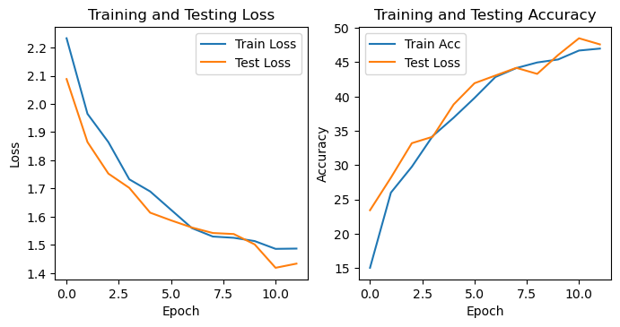

```python
plot_results(training_loss_2b, testing_loss_2b, training_acc_2b, testing_acc_2b)
```

```
Accuracy of the network on the 40000 test images: 48.83%
Weighted F1 score: 0.48
Weighted precision: 0.51
Weighted recall: 0.49
```

```
(48.825, 0.48126967508568186, 0.5105933361364392, 0.48825)
```

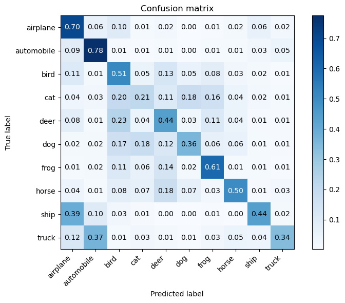

```python
test_model(trained_lenet5_2b, trainloader)
```

##### Adagrad

```python
num_epochs = 12
lr = 0.025
momentum = 0.9
batch_size = 256
optimizer_name = 'Adagrad'
trainloader, valloader, testloader, classes = load_data(batch_size)
lenet5_c = LeNet5()
trained_lenet5_2c, training_loss_2c, training_acc_2c, testing_loss_2c, testing_acc_2c = fit_model(lenet5_c, num_epochs, lr, momentum, optimizer_name, trainloader, valloader)
```

```
Files already downloaded and verified
Files already downloaded and verified
```

```
+-------+---------------+-----------------+-------------------+---------------------+
| Epoch | Training Loss | Validation Loss | Training Accuracy | Validation Accuracy |
+-------+---------------+-----------------+-------------------+---------------------+
|   1   |     1.9747    |      1.7262     |       26.23%      |        36.99%       |
|   2   |     1.7458    |      1.5286     |       39.94%      |        44.71%       |
|   3   |     1.6232    |      1.4727     |       43.87%      |        47.65%       |
|   4   |     1.6358    |      1.4370     |       48.02%      |        47.96%       |
|   5   |     1.6117    |      1.3822     |       49.33%      |        49.94%       |
|   6   |     1.6023    |      1.3684     |       49.76%      |        51.61%       |
|   7   |     1.4894    |      1.3474     |       52.33%      |        51.77%       |
|   8   |     1.4181    |      1.2819     |       54.05%      |        54.80%       |
|   9   |     1.4038    |      1.2603     |       52.22%      |        55.36%       |
|   10  |     1.4036    |      1.2316     |       54.51%      |        57.10%       |
|   11  |     1.3043    |      1.2624     |       55.78%      |        55.96%       |
|   12  |     1.3116    |      1.2152     |       57.56%      |        57.45%       |
+-------+---------------+-----------------+-------------------+---------------------+
```

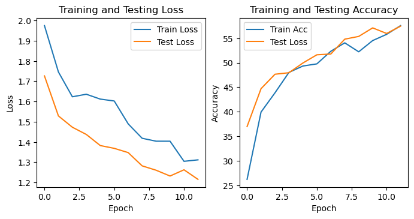

```python
plot_results(training_loss_2c, testing_loss_2c, training_acc_2c, testing_acc_2c)
```

```
Accuracy of the network on the 40000 test images: 61.57%
Weighted F1 score: 0.62
Weighted precision: 0.62
Weighted recall: 0.62
```

```
(61.5675, 0.6167018371371943, 0.6239130802896513, 0.615675)
```

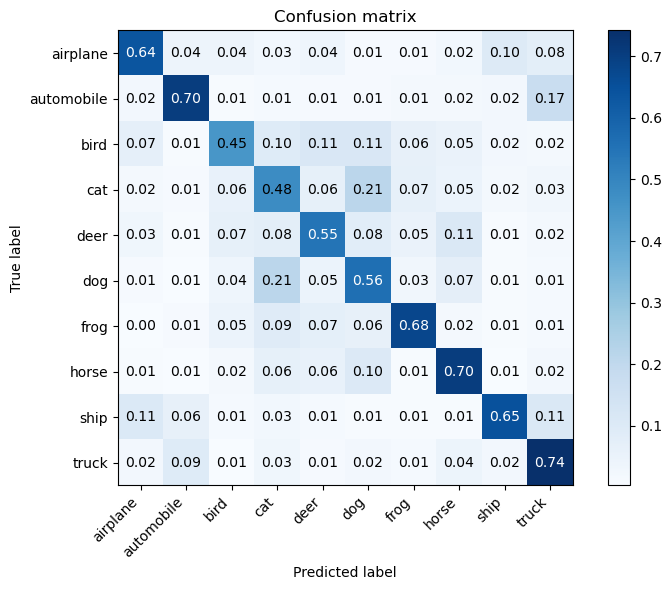

```python
test_model(trained_lenet5_2c, trainloader)
```

### Momentum

The following experiment will seek to understand the impact between a variety of momentum rates when training our LeNet5 model.

**Momentum = 0.0**

```python
num_epochs = 12
lr = 0.025
momentum = 0.0
batch_size = 256
optimizer_name = 'SGD'
trainloader, valloader, testloader, classes = load_data(batch_size)
lenet5_d = LeNet5()
trained_lenet5_2d, training_loss_2d, training_acc_2d, testing_loss_2d, testing_acc_2d = fit_model(lenet5_d, num_epochs, lr, momentum, optimizer_name, trainloader, valloader)
```

```
Files already downloaded and verified
Files already downloaded and verified
```

```
+-------+---------------+-----------------+-------------------+---------------------+
| Epoch | Training Loss | Validation Loss | Training Accuracy | Validation Accuracy |
+-------+---------------+-----------------+-------------------+---------------------+
|   1   |     2.3025    |      2.2991     |       10.65%      |        12.53%       |
|   2   |     2.2919    |      2.2769     |       15.61%      |        17.90%       |
|   3   |     2.2142    |      2.1372     |       20.12%      |        23.37%       |
|   4   |     2.0485    |      2.0292     |       25.00%      |        25.08%       |
|   5   |     1.9532    |      1.9272     |       28.33%      |        29.38%       |
|   6   |     1.8490    |      1.9415     |       32.20%      |        29.55%       |
|   7   |     1.7499    |      1.7276     |       36.06%      |        36.41%       |
|   8   |     1.6762    |      1.7533     |       39.15%      |        38.03%       |
|   9   |     1.6159    |      1.6042     |       41.33%      |        41.61%       |
|   10  |     1.5664    |      1.6514     |       42.96%      |        40.57%       |
|   11  |     1.5209    |      1.6620     |       44.89%      |        39.77%       |
|   12  |     1.4784    |      1.5674     |       46.15%      |        42.76%       |
+-------+---------------+-----------------+-------------------+---------------------+
```

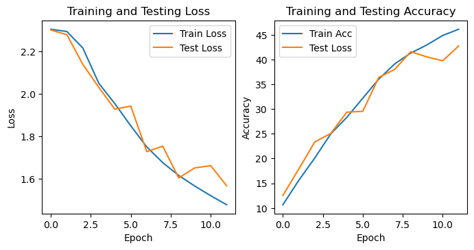

```python
plot_results(training_loss_2d, testing_loss_2d, training_acc_2d, testing_acc_2d)
```

```
Accuracy of the network on the 40000 test images: 43.44%
Weighted F1 score: 0.43
Weighted precision: 0.48
Weighted recall: 0.43
```

```
(43.4425, 0.4251783376439035, 0.4766370730856664, 0.434425)
```

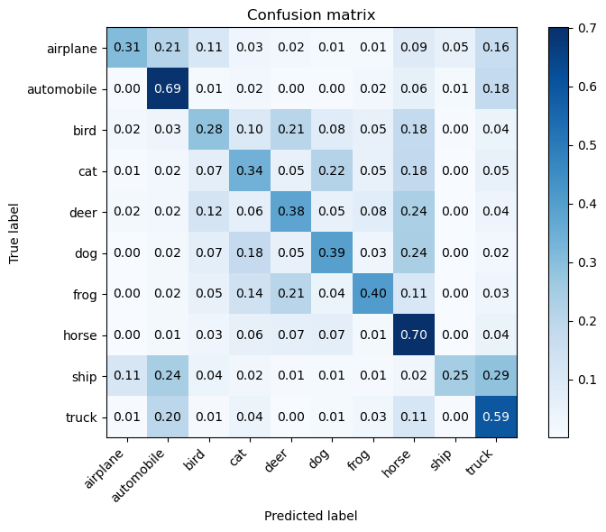

```python
test_model(trained_lenet5_2d, trainloader)
```

**Momentum = 0.5**

```python
num_epochs = 12
lr = 0.025
momentum = 0.5
batch_size = 256
optimizer_name = 'SGD'
trainloader, valloader, testloader, classes = load_data(batch_size)
lenet5_e = LeNet5()
trained_lenet5_2e, training_loss_2e, training_acc_2e, testing_loss_2e, testing_acc_2e = fit_model(lenet5_e, num_epochs, lr, momentum, optimizer_name, trainloader, valloader)
```

```
Files already downloaded and verified
Files already downloaded and verified
```

```
+-------+---------------+-----------------+-------------------+---------------------+
| Epoch | Training Loss | Validation Loss | Training Accuracy | Validation Accuracy |
+-------+---------------+-----------------+-------------------+---------------------+
|   1   |     2.2997    |      2.2924     |       12.67%      |        13.54%       |
|   2   |     2.2012    |      2.0010     |       19.19%      |        27.43%       |
|   3   |     1.9037    |      1.8304     |       30.78%      |        33.06%       |
|   4   |     1.7362    |      1.6510     |       36.41%      |        39.53%       |
|   5   |     1.6269    |      1.6139     |       40.54%      |        41.41%       |
|   6   |     1.5537    |      1.5506     |       43.84%      |        42.19%       |
|   7   |     1.4906    |      1.4736     |       45.93%      |        45.89%       |
|   8   |     1.4422    |      1.5138     |       47.99%      |        45.62%       |
|   9   |     1.3950    |      1.5714     |       49.93%      |        45.22%       |
|   10  |     1.3480    |      1.3712     |       51.81%      |        50.74%       |
|   11  |     1.3097    |      1.3451     |       53.29%      |        51.84%       |
|   12  |     1.2682    |      1.2716     |       54.79%      |        54.84%       |
+-------+---------------+-----------------+-------------------+---------------------+
```

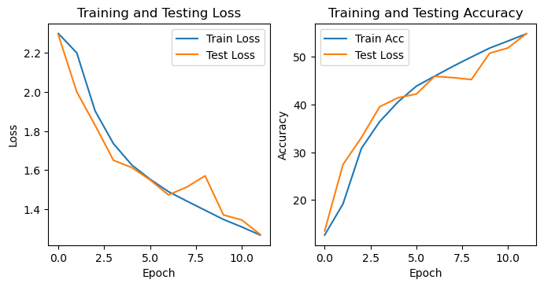

```python
plot_results(training_loss_2e, testing_loss_2e, training_acc_2e, testing_acc_2e)
```

```
Accuracy of the network on the 40000 test images: 56.38%
Weighted F1 score: 0.56
Weighted precision: 0.57
Weighted recall: 0.56
```

```
(56.3775, 0.5638164076806905, 0.5733259888030405, 0.563775)
```

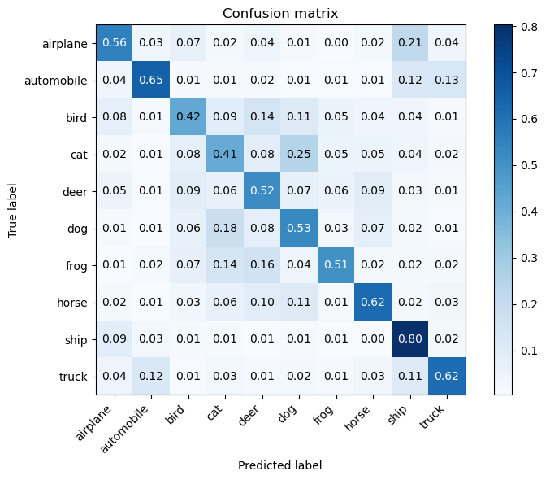

```python
test_model(trained_lenet5_2e, trainloader)
```

**Momentum = 0.99**

```python
num_epochs = 12
lr = 0.025
momentum = 0.99
batch_size = 256
optimizer_name = 'SGD'
trainloader, valloader, testloader, classes = load_data(batch_size)
lenet5_f = LeNet5()
trained_lenet5_2f, training_loss_2f, training_acc_2f, testing_loss_2f, testing_acc_2f = fit_model(lenet5_f, num_epochs, lr, momentum, optimizer_name, trainloader, valloader)
```

```
Files already downloaded and verified
Files already downloaded and verified
```

```
+-------+---------------+-----------------+-------------------+---------------------+
| Epoch | Training Loss | Validation Loss | Training Accuracy | Validation Accuracy |
+-------+---------------+-----------------+-------------------+---------------------+
|   1   |     2.0430    |      1.7983     |       23.32%      |        32.87%       |
|   2   |     1.6709    |      1.6187     |       37.86%      |        40.48%       |
|   3   |     1.5895    |      1.6450     |       41.42%      |        40.96%       |
|   4   |     1.5622    |      1.7009     |       43.32%      |        39.62%       |
|   5   |     1.5461    |      1.5120     |       43.88%      |        44.68%       |
|   6   |     1.4685    |      1.4957     |       47.16%      |        46.07%       |
|   7   |     1.4566    |      1.6034     |       48.30%      |        43.61%       |
|   8   |     1.4022    |      1.5022     |       50.54%      |        46.80%       |
|   9   |     1.4178    |      1.5305     |       50.57%      |        46.29%       |
|   10  |     1.3738    |      1.4820     |       52.13%      |        46.75%       |
|   11  |     1.3228    |      1.4541     |       53.90%      |        49.24%       |
|   12  |     1.3340    |      1.4966     |       53.66%      |        48.75%       |
+-------+---------------+-----------------+-------------------+---------------------+
```

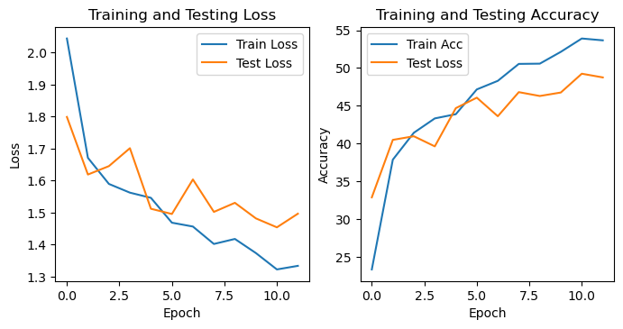

```python
plot_results(training_loss_2f, testing_loss_2f, training_acc_2f, testing_acc_2f)
```

```
Accuracy of the network on the 40000 test images: 52.36%
Weighted F1 score: 0.52
Weighted precision: 0.54
Weighted recall: 0.52
```

```
(52.3575, 0.5221662669340417, 0.5373280530380751, 0.523575)
```

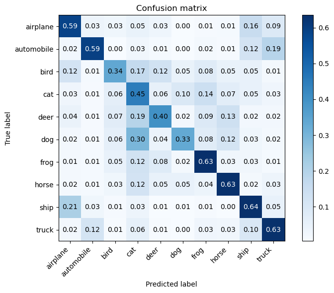

```python
test_model(trained_lenet5_2f, trainloader)
```

### Experiement 3 (AlexNet)

### Dropout Rate

Th following experiment seeks to explore the impact of a variety of dropout rates on our AlexNet implementation in order to find the optimal rate for our model. The dropout rate defines the probability that a given neuron's values are nullified and therefore can be useful to prevent overfitting.

**Dropout Rate = 0.5**

```python
num_epochs = 12
lr = 0.025
momentum = 0.9
batch_size = 256
optimizer_name = 'SGD'
trainloader, valloader, testloader, classes = load_data(batch_size)
alex_net_a = AlexNet(dropout_rate=0.5)
trained_alexnet_3a, training_loss_3a, training_acc_3a, testing_loss_3a, testing_acc_3a = fit_model(alex_net_a, num_epochs, lr, momentum, optimizer_name, trainloader, valloader)
```

```
Files already downloaded and verified
Files already downloaded and verified
```

```
+-------+---------------+-----------------+-------------------+---------------------+
| Epoch | Training Loss | Validation Loss | Training Accuracy | Validation Accuracy |
+-------+---------------+-----------------+-------------------+---------------------+
|   1   |     2.2998    |      2.2683     |       10.92%      |        15.45%       |
|   2   |     2.0271    |      1.7966     |       21.45%      |        30.34%       |
|   3   |     1.6835    |      1.5139     |       35.30%      |        41.73%       |
|   4   |     1.4379    |      1.3311     |       45.53%      |        50.85%       |
|   5   |     1.2650    |      1.2848     |       53.56%      |        53.54%       |
|   6   |     1.1069    |      1.0558     |       59.72%      |        61.58%       |
|   7   |     0.9748    |      1.0429     |       64.91%      |        63.02%       |
|   8   |     0.8663    |      1.0202     |       68.82%      |        64.66%       |
|   9   |     0.7733    |      0.9411     |       72.45%      |        67.59%       |
|   10  |     0.6682    |      0.8738     |       76.19%      |        69.84%       |
|   11  |     0.5746    |      0.8911     |       79.57%      |        69.87%       |
|   12  |     0.4946    |      0.8646     |       82.38%      |        71.78%       |
+-------+---------------+-----------------+-------------------+---------------------+
```

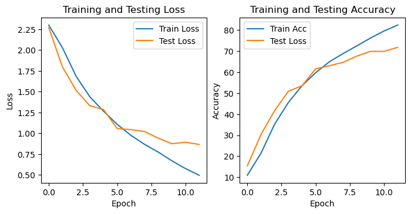

```python
plot_results(training_loss_3a, testing_loss_3a, training_acc_3a, testing_acc_3a)
```

```
Accuracy of the network on the 40000 test images: 87.76%
Weighted F1 score: 0.88
Weighted precision: 0.88
Weighted recall: 0.88
```

```
(87.76, 0.8778015274039633, 0.879837755445794, 0.8776)
```

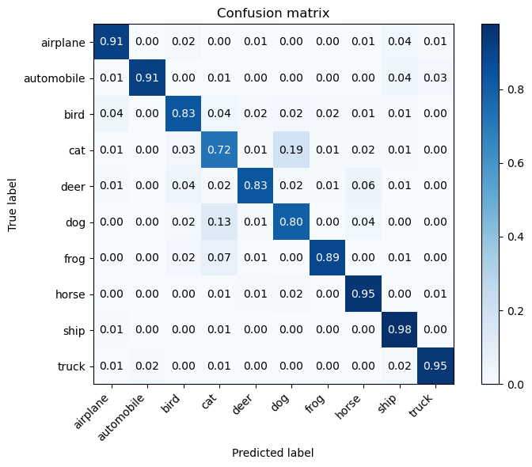

```python
test_model(trained_alexnet_3a, trainloader)
```

**Dropout Rate = 0.1**

```python
num_epochs = 12
lr = 0.025
momentum = 0.9
batch_size = 256
optimizer_name = 'SGD'
trainloader, valloader, testloader, classes = load_data(batch_size)
alex_net_b = AlexNet(dropout_rate=0.1)
trained_alexnet_3b, training_loss_3b, training_acc_3b, testing_loss_3b, testing_acc_3b = fit_model(alex_net_b, num_epochs, lr, momentum, optimizer_name, trainloader, valloader)
```

```
Files already downloaded and verified
Files already downloaded and verified
```

```
+-------+---------------+-----------------+-------------------+---------------------+
| Epoch | Training Loss | Validation Loss | Training Accuracy | Validation Accuracy |
+-------+---------------+-----------------+-------------------+---------------------+
|   1   |     2.2766    |      2.1955     |       12.60%      |        20.20%       |
|   2   |     1.8949    |      1.7069     |       25.84%      |        32.93%       |
|   3   |     1.5944    |      1.5325     |       38.40%      |        42.85%       |
|   4   |     1.3862    |      1.4252     |       48.12%      |        48.50%       |
|   5   |     1.2027    |      1.2073     |       55.74%      |        56.93%       |
|   6   |     1.0806    |      1.0772     |       60.73%      |        60.44%       |
|   7   |     0.9562    |      1.0984     |       65.32%      |        60.89%       |
|   8   |     0.8470    |      0.9964     |       69.32%      |        64.07%       |
|   9   |     0.7387    |      0.9366     |       73.41%      |        67.37%       |
|   10  |     0.6376    |      0.8606     |       77.19%      |        70.06%       |
|   11  |     0.5503    |      0.9253     |       80.55%      |        69.69%       |
|   12  |     0.4655    |      0.9276     |       83.56%      |        69.33%       |
+-------+---------------+-----------------+-------------------+---------------------+
```

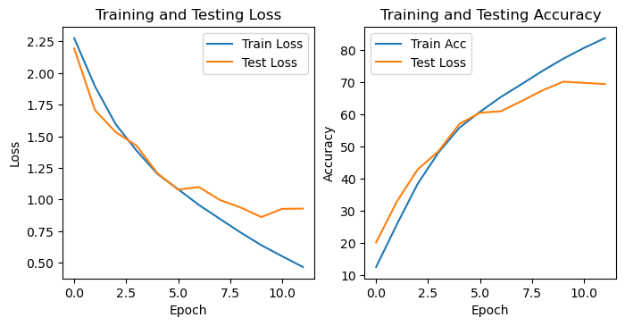

```python
plot_results(training_loss_3b, testing_loss_3b, training_acc_3b, testing_acc_3b)
```

```
Accuracy of the network on the 40000 test images: 85.10%
Weighted F1 score: 0.85
Weighted precision: 0.86
Weighted recall: 0.85
```

```
(85.1025, 0.8481331122844181, 0.8599878589652681, 0.851025)
```

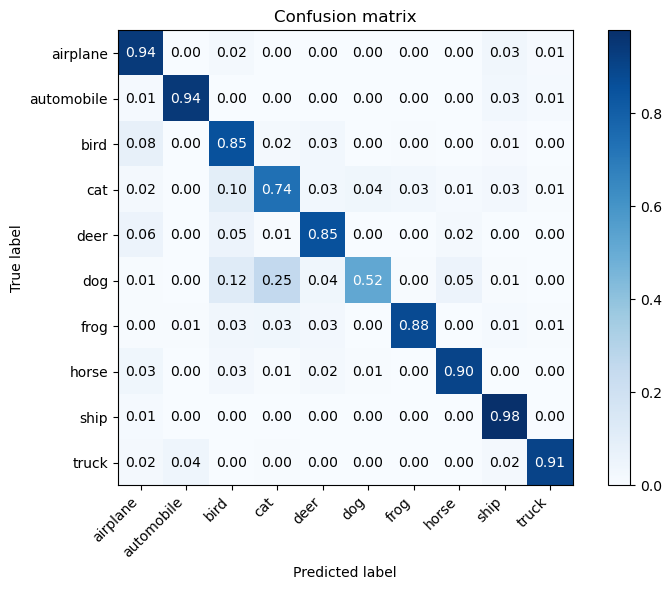

```python
test_model(trained_alexnet_3b, trainloader)
```

**Dropout Rate = 0.99**

```python
num_epochs = 12
lr = 0.025
momentum = 0.9
batch_size = 256
optimizer_name = 'SGD'
trainloader, valloader, testloader, classes = load_data(batch_size)
alex_net_c = AlexNet(dropout_rate=0.99)
trained_alexnet_3c, training_loss_3c, training_acc_3c, testing_loss_3c, testing_acc_3c = fit_model(alex_net_c, num_epochs, lr, momentum, optimizer_name, trainloader, valloader)
```

```
Files already downloaded and verified
Files already downloaded and verified
```

```
+-------+---------------+-----------------+-------------------+---------------------+
| Epoch | Training Loss | Validation Loss | Training Accuracy | Validation Accuracy |
+-------+---------------+-----------------+-------------------+---------------------+
|   1   |     2.2714    |      2.1516     |       11.53%      |        17.14%       |
|   2   |     2.1390    |      2.1361     |       16.58%      |        15.69%       |
|   3   |     2.1354    |      2.5081     |       15.83%      |        15.90%       |
|   4   |     2.0743    |      2.0023     |       16.90%      |        17.75%       |
|   5   |     2.0523    |      2.0840     |       17.34%      |        17.42%       |
|   6   |     2.0704    |      2.1143     |       16.85%      |        16.93%       |
|   7   |     2.1083    |      2.0179     |       16.42%      |        17.71%       |
|   8   |     2.0307    |      2.0807     |       17.86%      |        19.57%       |
|   9   |     2.0004    |      1.9941     |       18.82%      |        19.79%       |
|   10  |     2.0006    |      2.0485     |       19.41%      |        17.60%       |
|   11  |     1.9874    |      2.0495     |       19.79%      |        18.42%       |
|   12  |     1.9980    |      1.9929     |       19.50%      |        19.42%       |
+-------+---------------+-----------------+-------------------+---------------------+
```

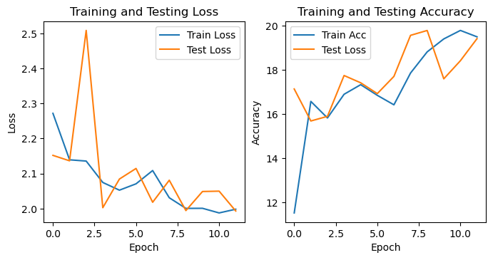

```python
plot_results(training_loss_3c, testing_loss_3c, training_acc_3c, testing_acc_3c)
```

```
Accuracy of the network on the 40000 test images: 10.01%
Weighted F1 score: 0.02
Weighted precision: 0.01
Weighted recall: 0.10
```

```
(10.0075, 0.02176271312912035, 0.012241765546868203, 0.100075)
```

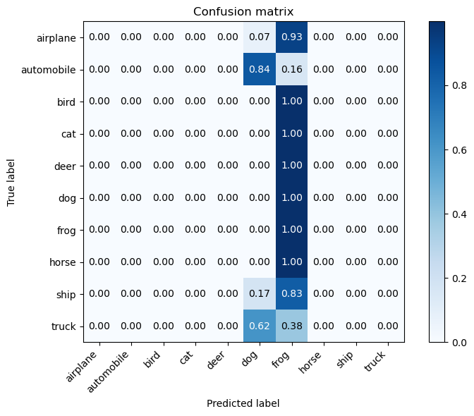

```python
test_model(trained_alexnet_3c, trainloader)
```